# READy Exercise

# 4 Results

## 4.1 Exploratory/Descriptive analysis

Table 1 shows a summary of the data.

| skim_type | skim_variable | n_missing | complete_rate | character.min | character.max | character.empty | character.n_unique | character.whitespace | factor.ordered | factor.n_unique | factor.top_counts | numeric.mean | numeric.sd | numeric.p0 | numeric.p25 | numeric.p50 | numeric.p75 | numeric.p100 | numeric.hist |
| --- | --- | --- | --- | --- | --- | --- | --- | --- | --- | --- | --- | --- | --- | --- | --- | --- | --- | --- | --- |
| character | Diet | 0 | 1 | 5 | 13 | 0 | 4 | 0 | NA | NA | NA | NA | NA | NA | NA | NA | NA | NA | NA |
| factor | Gender | 0 | 1 | NA | NA | NA | NA | NA | FALSE | 3 | M: 4, F: 3, O: 2 | NA | NA | NA | NA | NA | NA | NA | NA |
| numeric | Height | 0 | 1 | NA | NA | NA | NA | NA | NA | NA | NA | 165.666667 | 15.976545 | 133 | 156 | 166 | 178 | 183 | ▂▁▃▃▇ |
| numeric | Weight | 0 | 1 | NA | NA | NA | NA | NA | NA | NA | NA | 70.111111 | 21.245261 | 45 | 55 | 70 | 80 | 110 | ▇▂▃▂▂ |
| numeric | Sleep | 0 | 1 | NA | NA | NA | NA | NA | NA | NA | NA | 6.777778 | 1.481366 | 5 | 6 | 6 | 8 | 9 | ▅▇▁▇▂ |

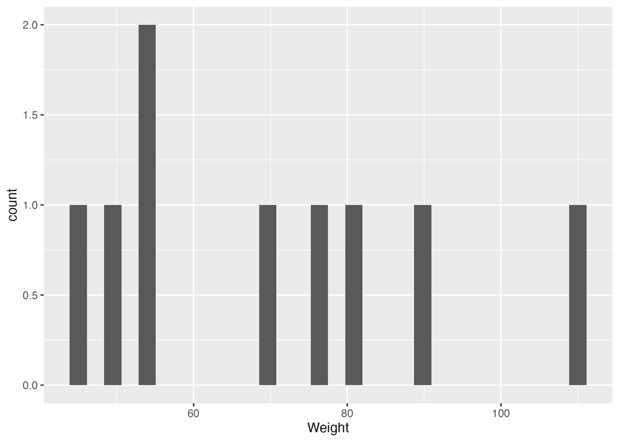

Figure 2: Histogram of Weight Distribution.

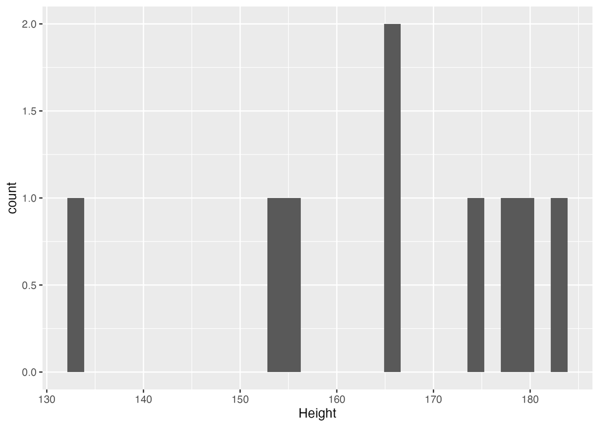

Figure 3: Histogram of Height Distribution.

## 4.2 Full Analysis

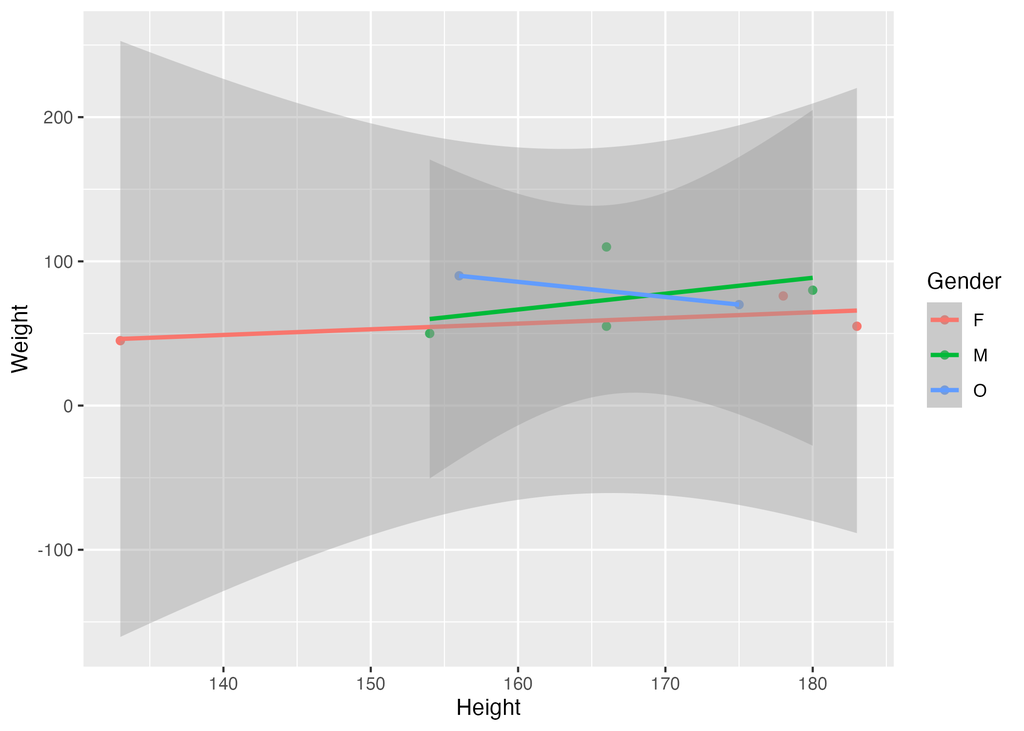

Figure 4: Height and weight stratified by gender.

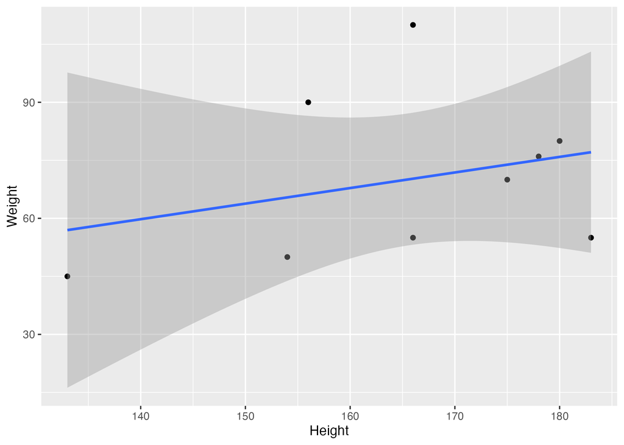

Figure 5: Weight vs Height with fitted linear regression.

Table 2 shows the association between `Height` and `Weight`; weight was not strongly associate with height (p-value= 0.43, estimate= 0.23).

Table 2: Model 1: Height ~ Weight.

| term | estimate | std.error | statistic | p.value |
| --- | --- | --- | --- | --- |
| (Intercept) | 149.6997661 | 19.7518528 | 7.5790240 | 0.0001285 |
| Weight | 0.2277371 | 0.2708841 | 0.8407177 | 0.4282860 |

Table 3: Model 2: Height ~ Weight + Gender.

| term | estimate | std.error | statistic | p.value |
| --- | --- | --- | --- | --- |
| (Intercept) | 149.2726967 | 23.3823360 | 6.3839942 | 0.0013962 |
| Weight | 0.2623972 | 0.3512436 | 0.7470519 | 0.4886517 |
| GenderM | -2.1244913 | 15.5488953 | -0.1366329 | 0.8966520 |
| GenderO | -4.7644739 | 19.0114155 | -0.2506112 | 0.8120871 |

Table 4: Model 3: Linear regression of Height on Sleep and Diet (Height ~ Sleep + Diet).

| term | estimate | std.error | statistic | p.value |
| --- | --- | --- | --- | --- |
| (Intercept) | 179.1176471 | 49.719417 | 3.6025693 | 0.0227062 |
| Sleep | -1.2941176 | 8.644132 | -0.1497105 | 0.8882383 |
| Dietomnivore | -11.0000000 | 30.865726 | -0.3563824 | 0.7395576 |
| Dietvegan | -0.8529412 | 21.026159 | -0.0405657 | 0.9695861 |
| Dietvegetarian | -3.7058824 | 22.319053 | -0.1660412 | 0.8761792 |

When we looked at `Height` distribution across different `Diet` categories, a few points stood out. Firstly, the categories were broadly overlapping. Both vegan and mediterranean categories had higher, though insignificantly higher, height on average.

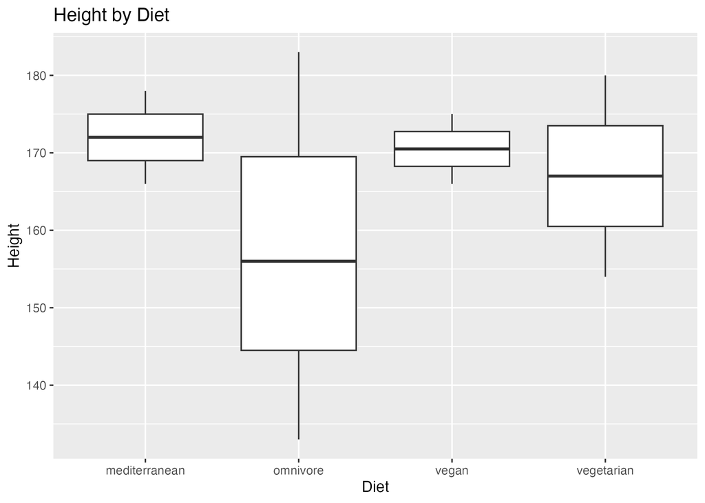

Figure 6: Height distribution stratified by Diet.

# 5 Discussion/Conclusion

## 5.1 Summary and Interpretation

In this READy exercise, we cleaned a small dataset (originally n=10) of height/weight/gender variables with two additional variables sleep/diet. We used basic plots and three linear regression models with height as the outcome. However, our analysis showed weak correlation across the new variables. Weight ended up not being a significant predictor, and the addition of gender did not change that. Sleep and diet also did not show association with height.

## 5.2 Strengths and Limitations

A great strength of this project is how reproducible the workflow is. All code and results are in respective relative paths accessable via our report.qmd.

The weaknesses lie in our small dataset, and imaginary data. Sleep and diet were added with no intention of creating a mock-significant result. Therefore, we should treat the results of this study as a learning exercise, and not draw conclusions from it.

This paper (1) discusses types of analyses.

These papers (2,3) are good examples of papers published using a fully reproducible setup similar to the one shown in this template.

## 6 References

1.

Leek JT, Peng RD. [Statistics. What is the question?](https://doi.org/10.1126/science.aaa6146) *Science (New York, N.Y.)*. 2015;347(6228):1314–1315.

2.

McKay B, Ebell M, Billings WZ, et al. [Associations Between Relative Viral Load at Diagnosis and Influenza A Symptoms and Recovery.](https://doi.org/10.1093/ofid/ofaa494) *Open forum infectious diseases*. 2020;7(11):ofaa494.

3.

McKay B, Ebell M, Dale AP, et al. [Virulence-mediated infectiousness and activity trade-offs and their impact on transmission potential of influenza patients.](https://doi.org/10.1098/rspb.2020.0496) *Proceedings. Biological sciences*. 2020;287(1927):20200496.